# notebook

# Crime Rate Prediction using Chicago Budget Data

## Overview

Regression analysis of Chicago crime rates against city budget data

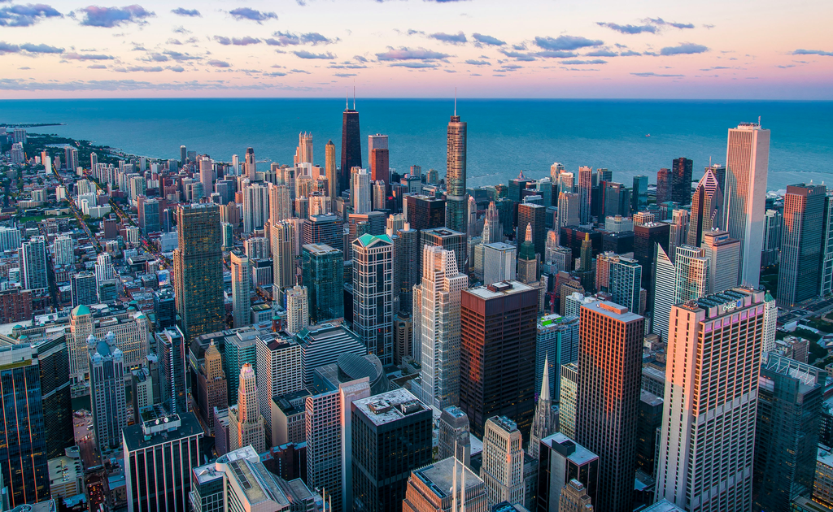

*Photo by [Pedro Lastra](https://unsplash.com/@peterlaster?utm_content=creditCopyText&utm_medium=referral&utm_source=unsplash) on Unsplash*

## 1. Business Understanding

### 1.1 Background

Crime is a central concern for many city and suburban residents, often leading to contentious discussions regarding city budgets. Proponents of increased police funding argue that it is essential for maintaining public safety. Conversely, there is a growing movement, rooted in the advocacy of activists like Martin Luther King Jr. and Angela Davis, calling for defunding or even abolishing the police. While this idea has existed for many years, it has gained significant momentum in recent times, particularly following the tragic murder of George Floyd by Minneapolis police officer Derek Chauvin.

This movement argues that redirecting funds from police departments toward public health programs, community centers, public parks, transportation, and affordable housing could create safer and more equitable communities by addressing the root causes of crime.

In cities like Chicago, these opposing viewpoints pose significant challenges for city officials tasked with determining annual budget allocations. Striking a balance between sectors such as education, parks, libraries, and public safety requires not only careful prioritization but also robust, data-driven decision-making to address both community needs and public safety concerns.

### 1.2 Goals

This project aims to develop an *inferential* model that predicts the crime rate in Chicago based on the city’s budget data. The primary goal is to identify which aspects of the budget—whether related to police funding, education, parks, libraries, or other services—are most strongly correlated with crime reduction. Specifically, this project seeks to evaluate the claim that increasing police spending directly results in a reduction in crime rates.

## 2. Data

### 2.1 Data Collection

This project utilized data from multiple sources, focusing on budget data (city and public school system), population data, and crime data. These datasets were compiled from different sources and formats to create a cohesive analysis.

**Population Data**

The population data was sourced from the Illinois Department of Public Health’s population census, compiled through the U.S. Department of Commerce’s 2020 Census. This dataset provided decennial population figures for the City of Chicago from 1980 to 2020.

**Crime Data**

Crime data was gathered from two main sources: 1. Chicago’s Open Data Portal: Provided recent crime data from 2001 to the present. 2. Chicago Police Department Annual Reports: Supplied historical crime data from 1980 to 2000.

In the compiled dataset, I added a column labeled `num_of_crimes`:

- For years 1980–2000, I manually entered data from the annual police department reports.
- For years 2001–present, I used the Open Data Portal to merge crime data into the spreadsheet during the data understanding phase.

**City Budget Data**

City budget data was collected from the Chicago City Clerk’s records database, which included annual appropriation ordinances dating back to 1982. From these reports, I extracted the following data points:

- Total appropriated budget
- Appropriations for specific departments:
- Police Department
- Department of Public Health
- Streets and Sanitation
- Public Library
- Department of Transportation
- Department of Family and Support Services
- Department of Housing
- Department of Planning and Development
- Office of Budget and Management (which funds the Parks Department)

I chose to focus on these departments and bureaus based on my domain knowledge and it feels like these are the ones that feel closest to affecting on the ground human life.

Public School System Budget Data

Public school budget data was sourced from the Chicago Public Schools (CPS) annual budget reports. CPS revenue generally falls into three categories: local, state, and federal funding.

### 2.2 Data Understanding

```r
# installing tidyverse packages
install.packages('tidyverse')
```

```r
# loading in tidyverse library
library(tidyverse)
library(dplyr)
library(lubridate)
```

```r
# reading in dataset
budget_df <- read_csv('./data/crime_rate_regression - Data.csv')
```

```r
str(budget_df)
```

```
spc_tbl_ [51 × 28] (S3: spec_tbl_df/tbl_df/tbl/data.frame)
 $ year                                     : num [1:51] 1980 1981 1982 1983 1984 ...
 $ population                               : num [1:51] 3005072 NA NA NA NA ...
 $ num_of_crimes                            : num [1:51] 196605 173316 181891 241603 276875 ...
 $ budget_and_mgmt_allocation               : num [1:51] NA NA NA NA NA NA NA NA NA NA ...
 $ arch_construct_energy_mgmt_allocation    : num [1:51] NA NA NA NA NA NA NA NA NA NA ...
 $ fleet_and_facil_mgmt_allocation          : num [1:51] NA NA NA NA NA NA NA NA NA NA ...
 $ dept_asset_info_and_services_allocation  : num [1:51] NA NA NA NA NA NA NA NA NA NA ...
 $ dept_planning_devel_allocation           : num [1:51] NA NA NA NA NA NA NA NA NA NA ...
 $ dept_of_housing_allocation               : num [1:51] NA NA NA NA NA NA NA NA NA NA ...
 $ registration_and_comm_services_allocation: num [1:51] NA NA NA NA NA NA NA NA NA NA ...
 $ public_health_allocation                 : num [1:51] NA NA NA NA NA NA NA NA NA NA ...
 $ child_youth_services_allocation          : chr [1:51] NA NA NA NA ...
 $ human_services_allocation                : num [1:51] NA NA NA NA NA NA NA NA NA NA ...
 $ fam_supp_services_allocation             : num [1:51] NA NA NA NA NA NA NA NA NA NA ...
 $ dept_housing_and_econ_devel_allocation   : num [1:51] NA NA NA NA NA NA NA NA NA NA ...
 $ comm_devel_allocation                    : num [1:51] NA NA NA NA NA NA NA NA NA NA ...
 $ police_allocation                        : num [1:51] NA NA NA NA NA NA NA NA NA NA ...
 $ envi_and_sustain_allocation              : num [1:51] NA NA NA NA NA NA NA NA NA NA ...
 $ streets_sanit_allocation                 : num [1:51] NA NA NA NA NA NA NA NA NA NA ...
 $ transportation_allocation                : num [1:51] NA NA NA NA NA NA NA NA NA NA ...
 $ CPL_building_and_sites_allocation        : num [1:51] NA NA NA NA NA NA NA NA NA NA ...
 $ CPL_building_sites_fin_general           : num [1:51] NA NA NA NA NA NA NA NA NA NA ...
 $ CPL_maintenance_and_ops_allocation       : num [1:51] NA NA NA NA NA NA NA NA NA NA ...
 $ other_ops_expenses_allocation            : num [1:51] NA NA NA NA NA NA NA NA NA NA ...
 $ library_allocation                       : logi [1:51] NA NA NA NA NA NA ...
 $ total_budget                             : num [1:51] NA NA NA NA NA NA NA NA NA NA ...
 $ cps_total_revenue ($ millions)           : chr [1:51] NA NA NA NA ...
 $ cps_state_revenue ($ millions)           : chr [1:51] NA NA NA NA ...
 - attr(*, "spec")=
  .. cols(
  ..   year = col_double(),
  ..   population = col_number(),
  ..   num_of_crimes = col_number(),
  ..   budget_and_mgmt_allocation = col_double(),
  ..   arch_construct_energy_mgmt_allocation = col_double(),
  ..   fleet_and_facil_mgmt_allocation = col_double(),
  ..   dept_asset_info_and_services_allocation = col_double(),
  ..   dept_planning_devel_allocation = col_double(),
  ..   dept_of_housing_allocation = col_double(),
  ..   registration_and_comm_services_allocation = col_double(),
  ..   public_health_allocation = col_double(),
  ..   child_youth_services_allocation = col_character(),
  ..   human_services_allocation = col_double(),
  ..   fam_supp_services_allocation = col_double(),
  ..   dept_housing_and_econ_devel_allocation = col_double(),
  ..   comm_devel_allocation = col_double(),
  ..   police_allocation = col_double(),
  ..   envi_and_sustain_allocation = col_double(),
  ..   streets_sanit_allocation = col_double(),
  ..   transportation_allocation = col_double(),
  ..   CPL_building_and_sites_allocation = col_double(),
  ..   CPL_building_sites_fin_general = col_double(),
  ..   CPL_maintenance_and_ops_allocation = col_double(),
  ..   other_ops_expenses_allocation = col_double(),
  ..   library_allocation = col_logical(),
  ..   total_budget = col_double(),
  ..   `cps_total_revenue ($ millions)` = col_character(),
  ..   `cps_state_revenue ($ millions)` = col_character()
  .. )
 - attr(*, "problems")=<externalptr>
```

[figure not shown]

```r
budget_df %>%
  select_if(is.numeric) %>%
  gather(key = 'Feature', value = "Value") %>%
  filter(!is.na(Value) & is.finite(Value)) %>%
  ggplot(aes(x = Value)) +
  geom_histogram(bins = 30, fill = 'skyblue', color = "black") +
  facet_wrap(~Feature, scales = "free_x", ncol = 3) +
  theme_minimal() +
  labs(title = "Histograms for Each Feature", x = "Value", y = "Frequency")
```

### 2.3 Data Preparation

```r
budget_2002_to_present <- subset(budget_df, year >= 2002 & year <= 2025)
```

```r
str(budget_2002_to_present)
```

```
tibble [24 × 28] (S3: tbl_df/tbl/data.frame)
 $ year                                     : num [1:24] 2002 2003 2004 2005 2006 ...
 $ population                               : num [1:24] NA 2896016 NA NA NA ...
 $ num_of_crimes                            : num [1:24] 194255 185458 178534 167839 166057 ...
 $ budget_and_mgmt_allocation               : num [1:24] NA 2497830 4352978 2434344 2845397 ...
 $ arch_construct_energy_mgmt_allocation    : num [1:24] NA NA NA NA NA ...
 $ fleet_and_facil_mgmt_allocation          : num [1:24] NA 57241375 NA NA NA ...
 $ dept_asset_info_and_services_allocation  : num [1:24] NA NA NA NA NA NA NA NA NA NA ...
 $ dept_planning_devel_allocation           : num [1:24] NA 12043526 12581990 11737577 13115694 ...
 $ dept_of_housing_allocation               : num [1:24] NA 14268618 14245550 15307726 15373788 ...
 $ registration_and_comm_services_allocation: num [1:24] NA 4092640 2578904 3146435 4237996 ...
 $ public_health_allocation                 : num [1:24] NA 43053368 37744294 35972313 36872690 ...
 $ child_youth_services_allocation          : chr [1:24] NA "n/a" "3509850" "3240555" ...
 $ human_services_allocation                : num [1:24] NA 14843008 6624591 6828321 7184371 ...
 $ fam_supp_services_allocation             : num [1:24] NA NA NA NA NA ...
 $ dept_housing_and_econ_devel_allocation   : num [1:24] NA NA NA NA NA NA NA NA NA NA ...
 $ comm_devel_allocation                    : num [1:24] NA NA NA NA NA ...
 $ police_allocation                        : num [1:24] NA 1.04e+09 1.05e+09 1.04e+09 1.19e+09 ...
 $ envi_and_sustain_allocation              : num [1:24] NA 4458950 3893380 3844054 3665329 ...
 $ streets_sanit_allocation                 : num [1:24] NA 2.37e+08 2.41e+08 2.38e+08 2.52e+08 ...
 $ transportation_allocation                : num [1:24] NA 42376226 40973513 39863335 34419101 ...
 $ CPL_building_and_sites_allocation        : num [1:24] NA 413500 392825 392825 467078 ...
 $ CPL_building_sites_fin_general           : num [1:24] NA NA NA NA NA NA NA NA NA 166000 ...
 $ CPL_maintenance_and_ops_allocation       : num [1:24] NA 47362472 42636537 44048924 50047554 ...
 $ other_ops_expenses_allocation            : num [1:24] NA 17183442 18996249 26758011 23028139 ...
 $ library_allocation                       : logi [1:24] NA NA NA NA NA NA ...
 $ total_budget                             : num [1:24] NA 5.10e+09 5.21e+09 5.42e+09 5.56e+09 ...
 $ cps_total_revenue ($ millions)           : chr [1:24] NA "3,874.10" "4,092.20" "4,200.90" ...
 $ cps_state_revenue ($ millions)           : chr [1:24] NA "$1,469.600" "1,481.40" "1,507.10" ...
```

```r
budget_2002_to_present <- budget_2002_to_present %>%
  mutate(`cps_state_revenue ($ millions)` = as.numeric(gsub("[^0-9.]", "", `cps_state_revenue ($ millions)`)))
```

```r
budget_2002_to_present <- budget_2002_to_present %>%
  mutate(`cps_total_revenue ($ millions)` = as.numeric(gsub("[^0-9.]", "", `cps_total_revenue ($ millions)`)))
```

```r
budget_2002_to_present[budget_2002_to_present == 'n/a'] <- NA
```

```r
budget_2002_to_present[] <- lapply(budget_2002_to_present, as.numeric)
```

```r
budget_2002_to_present$`cps_total_revenue` <- budget_2002_to_present$`cps_total_revenue ($ millions)` * 1000000
```

```r
budget_2002_to_present$`cps_state_revenue` <- budget_2002_to_present$`cps_state_revenue ($ millions)` * 1000000
```

```r
budget_2002_to_present$library_funding <- rowSums(budget_2002_to_present[, c("CPL_building_and_sites_allocation", "CPL_building_sites_fin_general", "CPL_maintenance_and_ops_allocation", "other_ops_expenses_allocation")], na.rm = TRUE)
```

```r
# combining funding for human, family, child, and community services into one bucket
budget_2002_to_present$human_and_comm_services_funding <- rowSums(budget_2002_to_present[, c("registration_and_comm_services_allocation", "child_youth_services_allocation", "human_services_allocation", "fam_supp_services_allocation")], na.rm = TRUE)
```

```r
# combining housing, planning and development, housing and economic development, and community development into one feature
budget_2002_to_present$house_and_comm_devel_funding <- rowSums(budget_2002_to_present[, c("dept_planning_devel_allocation", "dept_of_housing_allocation", "dept_housing_and_econ_devel_allocation", "comm_devel_allocation")], na.rm = TRUE)
```

```r
#parks and facilities mgmt
budget_df$arch_construct_energy_mgmt_allocation
```

```
 [1]       NA       NA       NA       NA       NA       NA       NA       NA       NA       NA       NA       NA       NA       NA       NA
[16]       NA       NA       NA       NA       NA       NA       NA       NA       NA       NA       NA       NA       NA       NA       NA
[31]       NA 17361700       NA       NA       NA       NA       NA       NA       NA       NA       NA       NA       NA       NA       NA
[46]       NA       NA       NA       NA       NA       NA
```

```r
budget_df$fleet_and_facil_mgmt_allocation
```

```
 [1]        NA        NA        NA        NA        NA        NA        NA        NA        NA        NA        NA        NA        NA        NA
[15]        NA        NA        NA        NA        NA        NA        NA        NA        NA  57241375        NA        NA        NA        NA
[29]        NA        NA        NA        NA 162111230 173134616 178470619 172557750 193209721 197754825 199378556 209962373        NA        NA
[43]        NA        NA 271447754 279266414        NA        NA        NA        NA        NA
```

```r
budget_df$dept_asset_info_and_services_allocation
```

```
 [1]        NA        NA        NA        NA        NA        NA        NA        NA        NA        NA        NA        NA        NA        NA
[15]        NA        NA        NA        NA        NA        NA        NA        NA        NA        NA        NA        NA        NA        NA
[29]        NA        NA        NA        NA        NA        NA        NA        NA        NA        NA        NA        NA 239953799        NA
[43]        NA 289453042        NA        NA        NA        NA        NA        NA        NA
```

```r
budget_2002_to_present$parks_facilities_and_environmental_funding <-rowSums(
  budget_2002_to_present[, c("arch_construct_energy_mgmt_allocation", "fleet_and_facil_mgmt_allocation", "dept_asset_info_and_services_allocation", "envi_and_sustain_allocation")], na.rm = TRUE)
```

```r
#removing columns that I combined
budget_2002_to_present <- budget_2002_to_present[, !colnames(budget_2002_to_present) %in% c(
  'CPL_building_and_sites_allocation',
  'CPL_building_sites_fin_general',
  'CPL_maintenance_and_ops_allocation',
  'other_ops_expenses_allocation',
  'library_allocation',
  'registration_and_comm_services_allocation',
  'child_youth_services_allocation',
  'human_services_allocation',
  'fam_supp_services_allocation',
  'dept_planning_devel_allocation',
  'dept_of_housing_allocation',
  'dept_housing_and_econ_devel_allocation',
  'comm_devel_allocation',
  'arch_construct_energy_mgmt_allocation',
  'fleet_and_facil_mgmt_allocation',
  'dept_asset_info_and_services_allocation',
  'cps_state_revenue ($ millions)',
  'cps_total_revenue ($ millions)',
  'transportation_allocation',
  'envi_and_sustain_allocation'
)]
```

```r
# interpolating population based on 10-year census data
budget_2002_to_present$year <- as.integer(budget_2002_to_present$year)

budget_2002_to_present$population <- approx(budget_2002_to_present$year, budget_2002_to_present$population, xout = budget_2002_to_present$year, rule = 2)$y
```

```r
# creating list of funding categories to find percentage of total budget
columns_to_percents <- c('library_funding', 'parks_facilities_and_environmental_funding', 'human_and_comm_services_funding', 'house_and_comm_devel_funding', 'streets_sanit_allocation', 'police_allocation', 'public_health_allocation', 'budget_and_mgmt_allocation')
```

```r
# Loop through each column in the list
for (col in columns_to_percents) {
  # Calculate percentage of total budget
  budget_2002_to_present[[paste0(col, "_percentage")]] <- round((budget_2002_to_present[[col]] / budget_2002_to_present$total_budget) * 100, digits = 4)
}
```

```r
budget_2002_to_present$cps_state_rev_percent_of_total <- round((budget_2002_to_present$cps_state_revenue / budget_2002_to_present$cps_total_revenue) * 100, digits = 4)
```

```r
crime_df <- read_csv('./data/Crimes_-_2001_to_Present_20241225.csv')
```

```r
colnames(crime_df)
```

```
 [1] "ID"                   "Case Number"          "Date"                 "Block"                "IUCR"                 "Primary Type"
 [7] "Description"          "Location Description" "Arrest"               "Domestic"             "Beat"                 "District"
[13] "Ward"                 "Community Area"       "FBI Code"             "X Coordinate"         "Y Coordinate"         "Year"
[19] "Updated On"           "Latitude"             "Longitude"            "Location"
```

```r
crime_df_filtered <- crime_df %>%
  mutate(date_parsed = mdy_hms(Date),
         year = year(date_parsed)) %>%
  filter(year(date_parsed) >= 2002 & year(date_parsed) <= 2025)
```

```r
rm(crime_df)
```

```r
crime_df_filtered <- crime_df_filtered %>%
  distinct(ID, `Case Number`, .keep_all = TRUE)
```

```r
#counts the number of reported crimes per year
crime_count_by_year <- crime_df_filtered %>%
  group_by(year) %>%
  summarise(crime_count = n())
```

```r
rm(crime_df_filtered)
```

```r
# merges crime_count_by_year onto budget_2002_to_present
budget_and_crime_cnt_df <- budget_2002_to_present %>%
  left_join(crime_count_by_year, by = 'year') %>%
  mutate(num_of_crimes = crime_count) %>%
  select(-crime_count)
```

```r
#drop years 2021 and 2022
budget_and_crime_cnt_df <- budget_and_crime_cnt_df %>%
  filter(!(year %in% c(2002, 2021, 2022)))
```

```r
#creates a crime rate column
budget_and_crime_cnt_df$crime_rate <- budget_and_crime_cnt_df$num_of_crimes / budget_and_crime_cnt_df$population
```

```r
colnames(budget_and_crime_cnt_df)
```

```
 [1] "year"                                                  "population"
 [3] "num_of_crimes"                                         "budget_and_mgmt_allocation"
 [5] "public_health_allocation"                              "police_allocation"
 [7] "streets_sanit_allocation"                              "total_budget"
 [9] "cps_total_revenue"                                     "cps_state_revenue"
[11] "library_funding"                                       "human_and_comm_services_funding"
[13] "house_and_comm_devel_funding"                          "parks_facilities_and_environmental_funding"
[15] "library_funding_percentage"                            "parks_facilities_and_environmental_funding_percentage"
[17] "human_and_comm_services_funding_percentage"            "house_and_comm_devel_funding_percentage"
[19] "streets_sanit_allocation_percentage"                   "police_allocation_percentage"
[21] "public_health_allocation_percentage"                   "budget_and_mgmt_allocation_percentage"
[23] "cps_state_rev_percent_of_total"                        "crime_rate"
```

## 3. Exploratory Data Analysis

## 4. Modeling

```r
modeling_df <- budget_and_crime_cnt_df %>%
  select(library_funding_percentage, parks_facilities_and_environmental_funding_percentage, human_and_comm_services_funding_percentage, house_and_comm_devel_funding_percentage, streets_sanit_allocation_percentage, police_allocation_percentage, public_health_allocation_percentage, budget_and_mgmt_allocation_percentage, cps_state_rev_percent_of_total, crime_rate)
```

## 5. Evaluation

## 6. Conclusion

### 6.1 Limitations

### 6.2 Recommendations

### 6.3 Next Steps

## 7. References